# **The Three True Outcomes of Baseball**

## Problem:

The impact of the increase of the "Three True Outcomes" in Major League Baseball on fan attendance of games.

## Background:

Think about a game of baseball. What makes it exciting? Close baseball games that are back-and-forth, where both teams are scoring, and it just feels intense. For example, take [this game between the Orioles and Tigers in the 2014 Playoffs](https://www.youtube.com/watch?v=zvs4TJgAHHg). The Orioles are down by 3 in the bottom of the 8th inning, in front of their fans, trying to comeback and win Game 2 of the series in the Playoffs. After a hit by pitch, a pair of singles (that scored 1 run), and a walk, Delmon Young hits a 3 RBI (3 runs batted in) Double to give the Orioles the lead. Even just watching at home, I can feel the electric energy of the crowd and it still makes me excited watching, even though I know exactly what happens.

Now, baseball is not everyone's favorite sport. But, the people who are fans of baseball, get extremely invested. To the point that there is a word, sabermetrics, specifically made for the statistical analysis of baseball. The sport is a multi-billion dollar industry that has a significant influence on American culture. Children decorate their whole bedroom for a baseball team, people make their wardrobe certain colors, have mugs, cups, and blankets, all to show support for their favorite baseball team. People love baseball; it is a big deal. And further on a macro scale, Major League Baseball recorded [10.7 billion dollars](https://www.cnbc.com/2019/12/22/report-mlb-revenue-for-2019-season-a-record-10point7-billion.html) in revenue in the 2019 season, which is quite a significant portion of the overall [money in the United States economy](https://en.wikipedia.org/wiki/Economy_of_the_United_States).

With how huge the sport of baseball is, coupled with a general growth in the population, one might expect that the attendance, one of the best measures of the sport's popularity, should be growing. Throughout the past several seasons, Major League Baseball (MLB) [fan attendance has been decreasing](https://www.forbes.com/sites/maurybrown/2019/10/04/from-terrible-teams-to-rising-costs-and-more-why-mlb-attendance-has-been-down-over-7-since-2015/?sh=79f014c031a8). This includes a 1.62% drop in attendance from 2018 to 2019, which was the most recent "normal" season of baseball, before the COVID-19 pandemic. And there have been steady declines for the last several seasons, which is more than just a one season fluke. There are a variety of factors for the recent decrease in attendance, but one of the main ones could be the increase in the "Three True Outcomes".

The "Three True Outcomes" (TTO) in baseball refer to Home Runs, Strikeouts, and Walks, which are 3 common outcomes of a plate appearance. A home run is when the batter hits the ball over the fence and automatically scores a run (or multiple runs if there are runners on base). A strikeout is when 3 strikes are thrown in one at bat to the batter, resulting in an out for the fielding team without the ball being put in play (barring foul balls or a dropped third strike). A walk is when a batter does not swing at 4 pitches that aren't in the strikezone, also known as balls, resulting in the batter being rewarded first base for a "base on balls", or a walk. Again barring foul balls (balls that are hit outside of the white lines on the field), a walk does not involve the ball being put in play. These 3 outcomes are grouped together in this statistic because all 3 of these outcomes only involve the batter, the Pitcher and the Catcher since the ball is never hit "in play" in these 3 outcomes (except for rare cases). It shrinks baseball down to an oversimplified version of the game where the 7 fielders behind the Pitcher are unnecessary. But, why does TTO matter? To put it simply, it makes baseball more boring. Think about it this way. Imagine you went to a baseball game where only TTO plate appearances happened (only Home Runs, Strikeouts, and Walks) for the entire game. Home runs are exciting, but they don't happen quite as much as walks or strikeouts. So, this hypothetical game consists of mainly strikeouts and walks, which means most batters who bat in this game won't even hit the ball. As in, the purpose of baseball for the batter, to hit the ball, will not even happen a majority of the time in this theoretical scenario. This type of game would just be boring to watch. Parts of baseball can be slow, but that is usually made up for with enough action in key moments through players getting on base and clutch base hits. This type of game takes away most of the opportunity for excitement there and renders a baseball game to be much less entertaining to watch if it just had home runs, walks, and strikeouts.

## Research questions:

- How has the perentage of Plate Appearances that resulted in one of the Three True Outcomes changed over time?
- How has fan attendance of MLB games changed the last decade?
- Is there any correlation between these changes in TTO rate and fan attendance?

## Importance of the questions:

As stated before, fan attendance has generally been decreasing the in recent years. And with baseball being a multi-billion dollar industry that a lot of people are invested in, a decrease in fans has a significant impact. It shows a decline in the success of the sport, which is notable considering baseball is called "America's past-time". So, I will be looking at how fan attendance has changed the past decade and analyzing if that drop really is that consequential. But of course, there have to be some factors for why the fan attendance has generally seemed to go down. There has also recently been an [increase in the number of home runs](https://www.mlb.com/news/mlb-releases-independent-study-of-home-run-surge), to the point that the MLB conducted an independent study to analyze the effects of a minor change in the stitching of the baseball on home runs. The relevance and magnitude of an increase in home runs recently has become large enough to justify the MLB conducting this study. Also during the recent years, the MLB has been constantly breaking its [record for strikeouts](https://www.si.com/mlb/2019/05/15/strikeout-record-pace-best-pitchers) every season. In 2019, they were up a whopping .9% from the previous year. This might not sound like much, but this near 1% increase represents 1,700 additional strikeouts, which is 5,100 additional strikes in the course of a full 162 game season. So, a .9% difference adds up over the season and really has an impact. With home runs and strikeouts rising, that will naturally increase the TTO rate (which is comprised of home runs, strikeouts, and walks) over the recent years. So with TTO rate on the rise, and fan attendance falling, that poses a question to see if there is any relationship between these two. Specifically, if there is any correlation between these trends becomes a compelling question. If so, this spots out a specific problem that the MLB could try to solve for, through tweaking certain rules of the game. Now of course, correlation does not equal causation, but with 2 potentially related factors here, it is not crazy to postulate that an increase in part of the game that is generally more boring would cause a decrease in fan attendance.

## Datasets used for this project:

[2019 Standard Batting (from Baseball Reference)](https://www.baseball-reference.com/leagues/MLB/2019.shtml#teams_standard_batting)

[2012 Standard Batting (from Baseball Reference)](https://www.baseball-reference.com/leagues/MLB/2012.shtml#teams_standard_batting)

[2014 Standard Batting (from Baseball Reference)](https://www.baseball-reference.com/leagues/MLB/2014.shtml#teams_standard_batting)

[2009 Standard Batting (from Baseball Reference)](https://www.baseball-reference.com/leagues/MLB/2009.shtml#teams_standard_batting)

[2004 Standard Batting (from Baseball Reference)](https://www.baseball-reference.com/leagues/MLB/2004.shtml#teams_standard_batting)

[1999 Standard Batting (from Baseball Reference)](https://www.baseball-reference.com/leagues/MLB/1999.shtml#teams_standard_batting)

[1994 Standard Batting (from Baseball Reference)](https://www.baseball-reference.com/leagues/MLB/1994.shtml#teams_standard_batting)

[1989 Standard Batting (from Baseball Reference)](https://www.baseball-reference.com/leagues/MLB/1989.shtml#teams_standard_batting)

[Attendance Each season in the 2010's](https://www.ballparksofbaseball.com/2010s-ballpark-attendance/)

Each of these datasets shows the team batting totals for each MLB team (all 30 of them) in various statistics in that respective season. While this chart includes many columns, the only ones needed here are the columns labeled "PA", "HR", "BB", and "SO". These stand for "Plate Appearances", "Home Runs", "Base on Balls" (also known as a "Walk"), and "Strikeouts" respectively. *Baseball Reference* allows the user to edit the dataset to eliminate certain columns (or rows), which I did on the website before downloading the Excel files and processing them into *JupyterLab*. We only need these 4 columns because the HR, BB, and SO are the 3 outcomes that make up the TTO, while the PA are the total of all TTO plus all non-TTO (anything else besides a home run, walk, or strikeout). The PA are needed because they allow the TTO to be seen as a percentage of all plate appearances, rather than raw totals, which makes it easier to compare between seasons. Side note: Plate Appearances are used rather than "At Bats" (AB) because the AB statistic does not include plate appearances that result in a hit by pitch, sacrifice bunt, sacrifice fly, or most importantly, a walk. This makes the plate appearances the more relevant total statistic of all possible hitting outcomes.

The reason I chose to use all 8 of these "Standard Batting" datasets is because this allows me to get TTO rate throughout a decent chunk of MLB history. I decided to get every 5 seasons because that was a close enough gap that it shows trends over time, but also far enough that I was able to cover 30 years in those datasets (1989-2019, every 5 years), which covers the MLB's recent years. Then, I also have the 2012 "Standard Batting" dataset because 2012 was [one of the last times attendance increased from the previous year](https://www.kansascity.com/sports/mlb/kansas-city-royals/article230089079.html). This makes it a compelling dataset for this project as that sets a relatively high bar for attendance, compared to the lower attendance in 2019. Also, the 2020 MLB season was severely shortened (60 games instead of 162) and also did not allow any fans to attend in the regular season, all due to the COVID-19 pandemic. The 2021 season has limited attendance, also due to COVID-19, which makes it an inaccurate comparison season too. This makes 2019 the most recent normal season in terms of fan attendance so that will be used as the bar for "current" fan attendance.

The last dataset shows the fan attendance for each MLB team in the 2010's decade. It includes total numbers for each team throughout the decade, as well as totals for each season, across the whole league. It does include new team names and new fields as separate entries in the dataset. The Atlanta Braves changed home fields in 2017, which is why there are some NULL values in the 2 different rows. In 2012, the "Florida Marlins" changed their name to the "Miami Marlins" which similarly results in some NULL values, and annoyingly moves those 2 rows away from each other because the rows are sorted alphabetically by city (or state) name. I'll be cleaning up those 2 rows of the data to make using this dataset easier for myself.

## Data Science Proces:

### Data Cleaning

```python
import pandas as pd
from scipy import stats
import matplotlib.pyplot as plt
import seaborn as sns
import numpy as np
from sklearn.linear_model import LinearRegression
from sklearn.model_selection import train_test_split
from sklearn import metrics
from scipy.stats import kendalltau
```

##### Reading in excel files (Batting from 1989-2019 every 5 years) + 2012 Batting + 2010's Attendance

```python
attendance = pd.read_csv("data/Attendance.csv")
batting_2012 = pd.read_excel("data/2012.xlsx")

batting_2019 = pd.read_excel("data/2019.xlsx")
batting_2014 = pd.read_excel("data/2014.xlsx")
batting_2009 = pd.read_excel("data/2009.xlsx")
batting_2004 = pd.read_excel("data/2004.xlsx")
batting_1999 = pd.read_excel("data/1999.xlsx")
batting_1994 = pd.read_excel("data/1994.xlsx")
batting_1989 = pd.read_excel("data/1989.xlsx")
```

##### Dropping the league total numbers at the bottom of each Batting dataset because those will not be needed.

```python
batting_2019 = batting_2019.drop(index=31)
batting_2014 = batting_2014.drop(index=31)
batting_2012 = batting_2012.drop(index=31)
batting_2009 = batting_2009.drop(index=31)
batting_2004 = batting_2004.drop(index=31)
batting_1999 = batting_1999.drop(index=31)
batting_1994 = batting_1994.drop(index=29)
batting_1989 = batting_1989.drop(index=27)
```

##### Adding a TTO column to each dataset

```python
batting_2019['TTO'] = round((batting_2019['HR'] + batting_2019['BB'] + batting_2019['SO']) / batting_2019['PA'], 5)
batting_2014['TTO'] = round((batting_2014['HR'] + batting_2014['BB'] + batting_2014['SO']) / batting_2014['PA'], 5)
batting_2012['TTO'] = round((batting_2012['HR'] + batting_2012['BB'] + batting_2012['SO']) / batting_2012['PA'], 5)
batting_2009['TTO'] = round((batting_2009['HR'] + batting_2009['BB'] + batting_2009['SO']) / batting_2009['PA'], 5)
batting_2004['TTO'] = round((batting_2004['HR'] + batting_2004['BB'] + batting_2004['SO']) / batting_2004['PA'], 5)
batting_1999['TTO'] = round((batting_1999['HR'] + batting_1999['BB'] + batting_1999['SO']) / batting_1999['PA'], 5)
batting_1994['TTO'] = round((batting_1994['HR'] + batting_1994['BB'] + batting_1994['SO']) / batting_1994['PA'], 5)
batting_1989['TTO'] = round((batting_1989['HR'] + batting_1989['BB'] + batting_1989['SO']) / batting_1989['PA'], 5)
# Adds a new row called 'TTO' to each dataset, which is the TTO value for each team in that given season
```

##### Cleaning out extraneous rows in the attendance dataset

```python
attendance['2017'][3] = attendance['2017'][2]
attendance['2018'][3] = attendance['2018'][2]
attendance['2019'][3] = attendance['2019'][2]
attendance = attendance.drop(index = 2)
## Due to the Atlanta Braves changing their stadium in 2017, that counts as a new index in the dataset I am using
## But it is the same team, so we can just count it as one index, and get rid of the NaN values, with these few lines of code
```

I chose to keep the old field for the Atlanta Braves as the field name that will stay in the dataset, just because that field was there for longer in the decade. Simiarly, the Miami Marlins were in Miami, as opposed to Florida (even though the city of Miami is in the state of Florida), for longer so I kept the index that has the location as Miami. This also stays consistent with the "MIA" abbreviation the Marlins have in the TTO datasets I am using.

```python
attendance['2010'][17] = attendance['2010'][12]
attendance['2011'][17] = attendance['2011'][12]
attendance = attendance.drop(index = 12)
## The Florida Marlins moved cities, changing their name to the Miami Marlins in 2012
## This also causes a new index in the dataset, which I do not need, so I will combine these two
```

##### Converting strings into ints

```python
attendance['2010'] = attendance['2010'].replace(",", "", regex=True)
attendance['2011'] = attendance['2011'].replace(",", "", regex=True)
attendance['2012'] = attendance['2012'].replace(",", "", regex=True)
attendance['2013'] = attendance['2013'].replace(",", "", regex=True)
attendance['2014'] = attendance['2014'].replace(",", "", regex=True)
attendance['2015'] = attendance['2015'].replace(",", "", regex=True)
attendance['2016'] = attendance['2016'].replace(",", "", regex=True)
attendance['2017'] = attendance['2017'].replace(",", "", regex=True)
attendance['2018'] = attendance['2018'].replace(",", "", regex=True)
attendance['2019'] = attendance['2019'].replace(",", "", regex=True)
attendance['Total'] = attendance['Total'].replace(",", "", regex=True)

# This removes all the commas from the strings in the dataframe, which will allow me to convert them to ints
```

```python
attendance['2010'] = pd.to_numeric(attendance['2010'])
attendance['2011'] = pd.to_numeric(attendance['2011'])
attendance['2012'] = pd.to_numeric(attendance['2012'])
attendance['2013'] = pd.to_numeric(attendance['2013'])
attendance['2014'] = pd.to_numeric(attendance['2014'])
attendance['2015'] = pd.to_numeric(attendance['2015'])
attendance['2016'] = pd.to_numeric(attendance['2016'])
attendance['2017'] = pd.to_numeric(attendance['2017'])
attendance['2018'] = pd.to_numeric(attendance['2018'])
attendance['2019'] = pd.to_numeric(attendance['2019'])

# This makes all the strings of numbers in the dataset into actual ints, which allows for mathematical calculations
```

##### Adjusting totals column

```python
attendance.loc[3, 'Total'] = attendance.loc[3, '2010':'2019'].sum()
attendance.loc[17, 'Total'] = attendance.loc[17, '2010':'2019'].sum()

# This adjusts the Totals column at the end to have the total from both Atlanta Braves' fields and both Marlins teams in the 2010's decade
```

### Data Science

Here is an example of one of the datasets, the 2019 batting, to get a sense of what the data looks like. Note that all the batting datasets have the same format, so the other ones look roughly the same as this one, just with different numbers of course. And note that the 1994 batting has 2 less indices (2 less teams in the league at that point) and the 1989 batting has 4 less indices (4 less teams) than all the other batting datasets (from 1999 on).

```python
batting_2019.head()
```

|  | Tm | PA | HR | BB | SO | TTO |
| --- | --- | --- | --- | --- | --- | --- |
| 0 | ARI | 6315 | 220 | 540 | 1360 | 0.33571 |
| 1 | ATL | 6302 | 249 | 619 | 1467 | 0.37052 |
| 2 | BAL | 6189 | 213 | 462 | 1435 | 0.34093 |
| 3 | BOS | 6475 | 245 | 590 | 1382 | 0.34239 |
| 4 | CHC | 6195 | 256 | 581 | 1460 | 0.37078 |

Let's also print out the attendance dataset, to give an idea of what the data we are working with looks like.

```python
attendance.head()
```

|  | Team | Ballpark | 2010 | 2011 | 2012 | 2013 | 2014 | 2015 | 2016 | 2017 | 2018 | 2019 | Total |
| --- | --- | --- | --- | --- | --- | --- | --- | --- | --- | --- | --- | --- | --- |
| 0 | NaN | TOTAL ATTENDANCE | 73171239 | 73451522 | 73951759 | 74026895 | 73739622 | 73760032 | 72976074 | 72670423 | 69649736 | 68478648 | 725875950 |
| 1 | Arizona Diamondbacks | Chase Field | 2056519 | 2105432 | 2177617 | 2134795 | 2073730 | 2080145 | 2036216 | 2134375 | 2242695 | 2135510 | 21177034 |
| 3 | Atlanta Braves | Turner Field | 2510119 | 2372940 | 2420171 | 2548679 | 2354305 | 2001392 | 2020914 | 2505252 | 2555781 | 2654920 | 23944473 |
| 4 | Baltimore Orioles | Camden Yards | 1733018 | 1755461 | 2102240 | 2357561 | 2464473 | 2320590 | 2172344 | 2028424 | 1564192 | 1307807 | 19806110 |
| 5 | Boston Red Sox | Fenway Park | 3046445 | 3054001 | 3043003 | 2833333 | 2956089 | 2880694 | 2955434 | 2917678 | 2895575 | 2924627 | 29506879 |

#### Let's check to see if the distribution of TTO values in a given season is normal

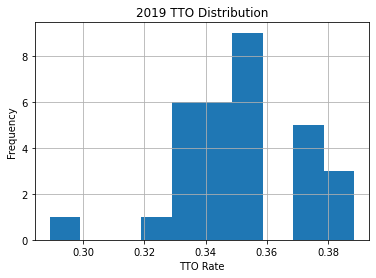

```python
batting_2019['TTO'].hist(bins = 10)
plt.xlabel("TTO Rate")
plt.ylabel("Frequency")
plt.title("2019 TTO Distribution")
plt.show()
```

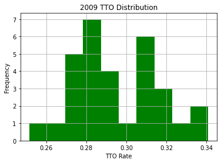

```python
batting_2009['TTO'].hist(bins = 10, color='green')
plt.xlabel("TTO Rate")
plt.ylabel("Frequency")
plt.title("2009 TTO Distribution")
plt.show()
```

We can see the graphs are not really normal. Generally more values clump together towards the middle and smaller frequency values are seen towards the ends. But they do not quite trend enough to be considered normal.

#### Let's also check to see if the distribution of fan attendance in a given season is normal

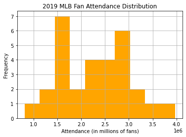

```python
attendance['2019'].tail(-1).hist(bins = 10, color='orange')
plt.xlabel("Attendance (in millions of fans)")
plt.ylabel("Frequency")
plt.title("2019 MLB Fan Attendance Distribution")
plt.show()
```

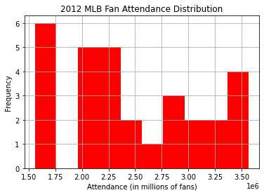

```python
attendance['2012'].tail(-1).hist(bins = 10, color='red')
plt.xlabel("Attendance (in millions of fans)")
plt.ylabel("Frequency")
plt.title("2012 MLB Fan Attendance Distribution")
plt.show()
```

We can see the distribution of attendance is not normal. 1.5-1.75 million seems to be a common range, but that is on the lower end of the spectrum of values here.

Now let's look at the TTO values over time, looking at every 5 years between 1989 to 2019 (inclusive).

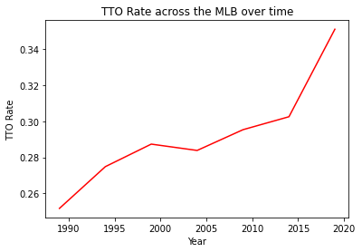

```python
TTO_values = [batting_1989.loc[26, 'TTO'], batting_1994.loc[28, 'TTO'], batting_1999.loc[30, 'TTO'], batting_2004.loc[30, 'TTO'], batting_2009.loc[30, 'TTO'], batting_2014.loc[30, 'TTO'], batting_2019.loc[30, 'TTO']]
Years = [1989, 1994, 1999, 2004, 2009, 2014, 2019]
plt.plot(Years, TTO_values, color='red')
plt.xlabel("Year")
plt.ylabel("TTO Rate")
plt.title("TTO Rate across the MLB over time")
plt.show()
```

We can see the TTO rate has been increasing almost every 5 years from 1989 to 2019. This shows a general increasing trend of home runs, strikeouts, and walks over the last 30 years of the MLB.

To compare more recent values, let's look at a boxplot of the 2012 TTO rates across the league versus those in 2019.

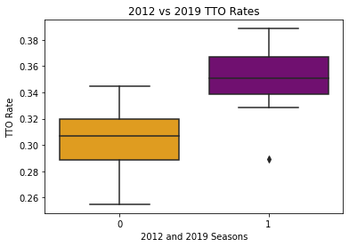

```python
TTO_arrays = [batting_2012['TTO'].head(-1), batting_2019['TTO'].head(-1)]
sns.boxplot(data = TTO_arrays, palette = ['orange', 'purple']).set(xlabel='Seasons', ylabel='TTO Rate')
plt.xlabel("2012 and 2019 Seasons")
plt.title("2012 vs 2019 TTO Rates")
plt.show()
```

The 2012 TTO rate is on the left (in the orange) and the 2019 TTO rate is on the right (in the purple). We can see that the 2019 TTO rate is higher for almost all values, showing a significant increase across the league. Now in the 2019 plot, there is an outlier very far down, around .29, which is the Pittsburgh Pirates. Keep the Pirates in mind with this next visualization.

```python
team_TTOchange = batting_2019['TTO'].head(-1) - batting_2012['TTO'].head(-1)
#team_TTOchange

## The reason I used .head(-1) here is because the last row of each dataset is the league average, which is not needed since we are looking at individual teams here
## Each index 0-29 represents 1 of the 30 MLB teams, the same order they appear in either the 2012, 2014, or 2019 datasets that appear in this project
```

```python
'''
plt.barh([team_TTOchange[i] for i in range (0,30)], [i for i in range (0,30)], color = 'blue')
plt.xticks([-.04, -.02, 0, .02, .04, .06, .08, .1])
#plt.xticks(indices, teams)
plt.yticks([j for j in range (0,30)], teamnames)
plt.ylabel("MLB Team Index - Alphabetical")
plt.xlabel("TTO Increase")
plt.title("TTO Increase from 2012 to 2019 by team")
plt.show()
'''
## I tried to make a horizontal bar chart but I couldn't figure it out and I decided to just make the plot below bigger,
## which allows me the space I needed to fit each team abbreviation in their index
```

[output not shown]

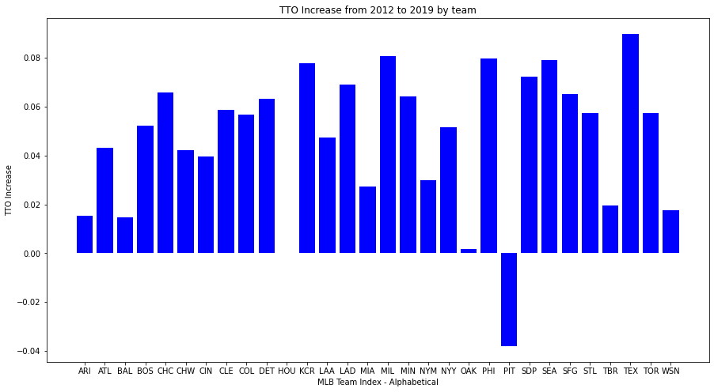

```python
plt.figure(figsize=(15,8))
plt.bar([i for i in range (0,30)], [team_TTOchange[i] for i in range (0,30)], color = 'blue')
plt.xticks([j for j in range (0,30)], [batting_2019.loc[i, 'Tm'] for i in range(0,30)])
plt.xlabel("MLB Team Index - Alphabetical")
plt.ylabel("TTO Increase")
plt.title("TTO Increase from 2012 to 2019 by team")
plt.show()
```

We can see that almost every single team in the league had an increase in TTO rate, with the only exception being the Pittsburgh Pirates. 29 out of 30 teams saw its TTO rate increase in from 2012 to 2019, which shows this as a league-wide trend, much more than just a fluke for a few teams. This graph in addition to the previous boxplot show the consistency of the general increase in TTO rate. Also note that while the Houston Astros (HOU) might look like they have a 0 change, they do have a slight increase (it is just small enough that it is not shown with the current yscale).

Now let's do a similar process, looking at the boxplots of 2012 fan attendance versus 2019 fan attendance.

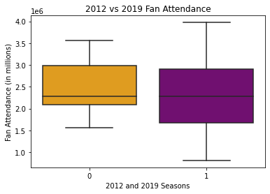

```python
att_arrays = [attendance.loc[1:32, '2012'], attendance.loc[1:32, '2019']]
sns.boxplot(data = att_arrays, palette = ['orange', 'purple']).set(xlabel='Seasons', ylabel='Fan Attendance (in millions)')
#plt.xticks([2012, 2019])
plt.xlabel("2012 and 2019 Seasons")
plt.title("2012 vs 2019 Fan Attendance")
plt.show()

## I tried to fix the xticks to be the season year (2012 and 2019) but I kept running into errors and never found a clean solution in seaborn plot
```

With the 2012 (orange) fan attendance on the left and the 2019 (purple) fan attendance on the right, we can see the attendance generally went somewhat down, but not by too much. The median is about the same, but the Q1 and minimum are much lower, with the Q3 very slightly lower, so that points to a generally decreasing trend. Although the maximum did increase from 2012 to 2019 actually.

```python
team_TTO_percentchange = round(team_TTOchange / batting_2012['TTO'].head(-1), 5)
## Making this a percentage will make it easier to compare to the attendance change percentage and see any correlation between the two

attendance['Change'] = attendance['2019'] - attendance['2012']
attendance['% change'] = round(attendance['Change']/attendance['2012'], 5)
```

This added 2 columns to the attendance dataset: 1 for the change between the 2012 and 2019 seasons and then one for the % change of that difference. The % change is useful because that puts this data on the same scale as the % change for the TTO rates. So let's look at these changes graphed together.

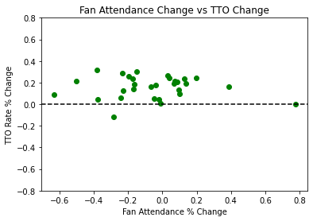

```python
#plt.scatter([i for i in range (0,30)], attendance.loc[1:32, '% change'], color='red')
#plt.scatter([i for i in range (0,30)], [team_TTO_percentchange[i] for i in range (0,30)], color='blue')
plt.scatter(attendance.loc[1:32, '% change'], [team_TTO_percentchange[i] for i in range (0,30)], color='green')
plt.yticks([-.8, -.6, -.4, -.2, 0, .2, .4, .6, .8])
plt.xlabel("Fan Attendance % Change")
plt.ylabel("TTO Rate % Change")
plt.title("Fan Attendance Change vs TTO Change")
plt.axhline(y = 0, color = 'black', linestyle = '--')
plt.show()
```

We have the Fan Attendance % change on the x-axis plotted versus the TTO rate % change on the y-axis. We would expect that at the fan attendance is at its sharpest decrease (the most negative x-values, towards the left), the TTO increase is at its highest. And that as we move along the x-axis (positive attendance change), the TTO rate % change would go down. We can see this somewhat, with some values trending downward, but not too much. We would expect a negative correlation so the inverse relationship we can somewhat see does make sense. But let's see if there is any statistical correlation. First, let's look at the % change distributions and see if they are normal.

##### Test for normalcy of distributions

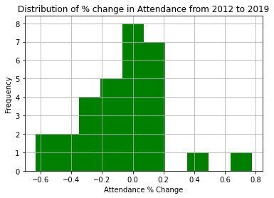

```python
attendance.loc[1:32, '% change'].hist(bins = 10, color='green')
plt.xlabel("Attendance % Change")
plt.ylabel("Frequency")
plt.title("Distribution of % change in Attendance from 2012 to 2019")
plt.show()
```

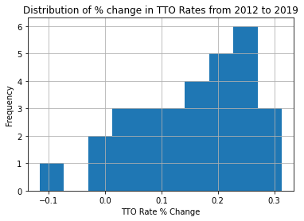

```python
team_TTO_percentchange.hist(bins = 10)
plt.xlabel("TTO Rate % Change")
plt.ylabel("Frequency")
plt.title("Distribution of % change in TTO Rates from 2012 to 2019")
plt.show()
```

We can see that neither of these distributions are normal, which probably makes sense considering both of the datasets they came from are not normal. And since they are not normal, that rules out Pearson's test for correlation. So let's try to Kendall Tau test for correlation.

```python
kendalltau(attendance.loc[1:32, '% change'], [team_TTO_percentchange[i] for i in range (0,30)])
```

```
KendalltauResult(correlation=-0.011494252873563218, pvalue=0.9436180468092228)
```

The correlation is almost 0 so this does not help to show any trend between TTO rate and fan attendance. Now, the correlation should be negative (which it is here) since the TTO rate is increasing over the past decade, while fan attendance is decreasing. However, this test shows there is no significant correlation between these numbers, at least on a micro scale, by the individual team.

Perhaps let's look at the top 5 highest increases in TTO rate and see if there is anything noteworthy with the fan attendance change for those teams.

```python
batting_2019['TTO % Change'] = team_TTO_percentchange
#batting_2019

## Adding in the changes into the batting_2019 dataset will make some calculations easier through Pandas
```

```python
top5_TTO = batting_2019.sort_values(by=['TTO % Change'], ascending=False).head(5)
top5_TTO
```

|  | Tm | PA | HR | BB | SO | TTO | TTO % Change |
| --- | --- | --- | --- | --- | --- | --- | --- |
| 27 | TEX | 6204 | 223 | 534 | 1578 | 0.37637 | 0.31359 |
| 11 | KCR | 6080 | 162 | 456 | 1405 | 0.33273 | 0.30564 |
| 20 | PHI | 6261 | 215 | 562 | 1453 | 0.35617 | 0.28856 |
| 15 | MIL | 6309 | 250 | 629 | 1563 | 0.38707 | 0.26283 |
| 23 | SEA | 6199 | 239 | 588 | 1581 | 0.38845 | 0.25554 |

```python
top5_TTOchanges = np.array(top5_TTO['TTO % Change'])
#top5_TTOchanges
```

The top 5 increases in TTO rates from 2012 to 2019 are from the Texas Rangers, Milwaukee Brewers, Philadelphia Phillies, Seattle Mariners, and Kansas City Royals, with their respective team indices shown. So let's grab all of their fan attendance changes as well.

```python
top5_TTOattendance = np.array(attendance.loc[[30,14,23,18,27] , '% change'])

attendance.loc[[30,14,23,18,27] , ['Team','% change']]
## Note that because of some weird indexing (with 2 indices for the Braves & 2 for the Marlins), the indices from the above chart are not all the same ones needed below
```

|  | Team | % change |
| --- | --- | --- |
| 30 | Texas Rangers | -0.38357 |
| 14 | Kansas City Royals | -0.14955 |
| 23 | Philadelphia Phillies | -0.23510 |
| 18 | Milwaukee Brewers | 0.03247 |
| 27 | Seattle Mariners | 0.04066 |

These are the % change in fan attendance of the 5 teams with the largest increase in TTO rate. Let's look at the bottom 5 % changes in fan attendance and see if any of these teams appear, showing a potential (inverse) correlation. The reason we want the bottom 5 % changes in fan attendance is because we are looking for an inverse correlation. As in, with the 5 teams who increased their TTO rate the most, did they also have the sharpest decrease in fan attendance?

```python
top5_attendance = attendance.sort_values(by=['% change'], ascending=False).tail(5)
top5_attendance.loc[:, ['Team','% change']]
```

|  | Team | % change |
| --- | --- | --- |
| 24 | Pittsburgh Pirates | -0.28705 |
| 4 | Baltimore Orioles | -0.37790 |
| 30 | Texas Rangers | -0.38357 |
| 11 | Detroit Tigers | -0.50416 |
| 17 | Miami Marlins | -0.63446 |

We can see that the Texas Rangers show up with the largest increase in TTO rate and the 3rd largest decrease in fan attendance. But outside of the Rangers, none of the other teams with a top 5 TTO increase also had a top 5 decrease in fan attendance (or bottom 5 increase in fan attendance).

We can also look at a graph of the Top 5 TTO increases and the fan attendance increases (both as a % change) to further contextualize these numbers.

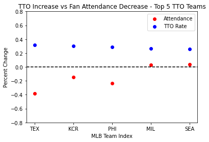

```python
plt.scatter([i for i in range (0,5)], top5_TTOattendance, color='red')
plt.scatter([i for i in range (0,5)], top5_TTOchanges, color='blue')
teams = ["TEX", "KCR", "PHI", "MIL", "SEA"]
indices = [0, 1, 2, 3, 4]
plt.xticks(indices, teams)
plt.yticks([-.8, -.6, -.4, -.2, 0, .2, .4, .6, .8])
plt.xlabel("MLB Team Index")
plt.ylabel("Percent Change")
plt.title("TTO Increase vs Fan Attendance Decrease - Top 5 TTO Teams")
plt.legend(['Attendance', 'TTO Rate'])
plt.axhline(y = 0, color = 'black', linestyle = '--')
plt.show()
```

We can see that not even all 5 of the largest TTO increase teams have negative fan attendance percent changes. As in, some teams saw increases in their TTO rate, but also saw their fan attendance increase during that same span, including 2 of these 5 teams. The 5 teams here are a small sample size, but if there was more of a correlation between increasing TTO rate and decreasing attendance, we would probably see all 5 red points here be negative.

## Interpreting Results:

We can see that fan attendance is considerably decreasing and that the TTO % is considerably increasing, but it is difficult to prove the causation between the two. On the surface it makes sense to draw a connection, as most fans do not want to pay money to see more boring Walks and Strikeouts, and that could explain a decrease in fan attendance. But the reality is that there are many other factors that would affect a fan's willingness and desire to come to a baseball game, including weather, free time, financial situation of the fans, and more.

We can see the lack of correlation with the Kendall Tau test conducted in this project. With a correlation of -.01149 and a p-value of .94362, there is essentially no relevant correlation, at least on a micro scale for individual teams. In other words, there was not a specific trend from each team that has a higher TTO rate also having decreased fan attendance. The reality of this is that different teams in different cities will draw in different numbers of fans. Often that is based on how good the team is or if they have any super dynamic, interesting players (especially Pitchers) that fans want to come watch. For example, the Los Angeles Dodgers who have steadily been one of the best teams in baseball for the last decade, saw an increase by about 650,000 fans from 2012 to 2019. Or another example is the Los Angeles Angels who saw their attendance increase by about 850,000. This is likely partially due to having the incredibly talented Shohei Ohtani, a Japanese player who is both a Pitcher and a Fielder, which is incredibly rare to see on a Major League level. And these factors likely affect a fan's willingness to see their local team play more than there being a few more strikeouts the past couple years.

However, we can also see the generally consistently increasing TTO rate since 1989, including an especially high bolt from 2014 to 2019. As sabermetrics has gotten even more common, players want to swing for home runs even more now, which has increased both home runs and strikeouts. We can see this with the aforementioned TTO rate across the MLB over time graph, as well as on the TTO Increase from 2012 to 2019 by team graph. It is astounding that 29 out of 30 teams have increased their TTO rate across that 7 year span. And with how sharp that recent spike is, it becomes very likely to expect that trend to only continue in the years to come.

Then with the fan attendance, we can see some trends of it generally going down. But, as seen on the boxplot of 2012 versus 2019 fan attendance, or on the distribution of % change of attendance, that downward trend is not ubiquitously seen across the league. Some teams, like the aforementioned Angels, Dodgers, and also the Houston Astros have seen their attendance increase the past decade, just to name a few teams. While there are more teams in the negative direction than positive when it comes to fan attendance, it is not quite enough concern for the MLB to believe its league will crash and burn. But, as the numbers indicate, it is something to look out for and these trends continuing over longer periods of time could have more serious negative impacts.

## Ethical Concerns:

Major League Baseball has already adjusted some rules to the game to try to make the games more exciting and dynamic to watch. In 2019, the MLB added a rule that a pitcher must pitch to at least 3 batters, barring an injury or the end of the half inning. This was designed to mitigate the slow process of relief pitchers coming in for just 1 batter, which made the games longer, and generally less entertaining. Some additional rule changes like a pitch clock, larger strikezone, or a farther back mound are being considered to help speed up the game and make fans want to watch more. This is relevant to the TTO statistic because some of these changes could decrease walks, decrease home runs, and likely increase the number of balls in play. If this project were to find its way to the MLB, and they realized there could be a connection between an increasing TTO rate and decreasing fan attendance, they would want to do everything they can to decrease the TTO rate. This could mean expediting rule changes, like the aforementioned pitch clock, larger strikezone, and/or farther mound to help the batters. This would hopefully result in more balls batted in play, more runners on base, and more entertaining baseball.

On the other side of that, more rule changes could complicate the viewing experience for fans, maybe to a point that fans do not want to watch baseball as much and would come to games even less. When it comes to rule changes, the MLB has a difficult task of trying to keep the game of baseball's core values, while also being willing to adapt and change to make the game better. There's a delicate balance that the MLB has to find and the tremendous increase in TTO rate as of late brings up the topic of any potential rule changes to the surface.

One of the stakeholders in the increase of TTO plate appearances is the fans themselves. There is the factor of fans going or not going to games, but beyond the field itself, fans are talking about TTO as a metric. Fans are even looking up to certain players like [Adam Dunn](https://www.youtube.com/watch?v=jiZfc0b2t3Q) or Rob Deer for their oddly specific skill of rarely making the fielders have to ... field. With how popular sabermetrics has become, maybe more and more fans are getting interested in the analytics side of the game rather than paying money to go watch a game live. And [some would argue](https://chroniclet.com/news/239403/true-outcome-analytics-making-for-boring-games-this-postseason/) that the increase in analytics, has lead to more boring baseball.

Another group of people involved is the players. If the players become hyper-aware of their increasing TTO rate, maybe some of them aim to hit the ball in play more and keep their TTO rates low. Certainly, these players that strive to put the ball in play still exist. Take [Hanser Alberto](https://www.baseball-reference.com/players/a/alberha01.shtml), a former infielder for the Baltimore Orioles, who finished the 2019 season with a .14182 TTO rate, which is way below the league average. But also, people like to be rebellious and some players might further accentuate the problem of increasing TTO rate even if they are aware.

If the decrease of fans gets drastic enough, teams might have to lay off workers, both personnel in the team and people who work at the stadium. During the 2020 season, due to COVID, [39,000 stadium workers](https://www.thenation.com/article/society/baseball-stadium-workers-crisis/) lost their jobs. Now, that was a much more extreme case when there were not allowed to be any fans at all, so there were many more layoffs, but that could be the reality for some ballpark workers if the decrease in fans is consistent enough the next decade. Then if the loss of revenue gets large enough, certain players might be laid off and/or some teams might not quite have the finances needed to give the players the salaries they are demanding. The decrease in fan attendance could become a bigger issue if it persists into the 2020's decade.